# Project 8 - Ainazik Amiraeva

# Lung Capacity

### March 17 2024

##### For this project, I conducted a complete analysis on the dataset, including full EDA, data prep/cleansing, and inferential analysis. Then I created 3 different models:

##### 1 - model1 = LungCap vs Height + error

##### 2 - model2 = LungCap vs (Height + Height**2) + error

##### 3 - model3 = LungCap vs (Height + Height**2 + Height**3) + error

```python
# Importing libraries
import pandas as pd
import numpy as np
import statsmodels.api as sm
from statsmodels.formula.api import ols
import matplotlib.pyplot as plt
import seaborn as sns
```

```python
# Load the dataset into a data frame
lungcapacity_df = pd.read_excel ('/Users/ajnazikamir/Desktop/LungCapData2.xlsx')
lungcapacity_df
```

|  | Age | LungCap | Height | Gender | Smoke |
| --- | --- | --- | --- | --- | --- |
| 0 | 9 | 3.124 | 57.0 | female | no |
| 1 | 8 | 3.172 | 67.5 | female | no |
| 2 | 7 | 3.160 | 54.5 | female | no |
| 3 | 9 | 2.674 | 53.0 | male | no |
| 4 | 9 | 3.685 | 57.0 | male | no |
| ... | ... | ... | ... | ... | ... |
| 649 | 16 | 10.810 | 67.0 | male | yes |
| 650 | 15 | 9.181 | 68.0 | male | yes |
| 651 | 18 | 6.559 | 60.0 | female | no |
| 652 | 16 | 6.385 | 63.0 | female | yes |
| 653 | 15 | 7.633 | 66.5 | female | no |

654 rows × 5 columns

## Descriptive statistical analysis

```python
# Display the first few rows of the DataFrame to understand its structure
print(lungcapacity_df.head())
```

```
   Age  LungCap  Height  Gender Smoke
0    9    3.124    57.0  female    no
1    8    3.172    67.5  female    no
2    7    3.160    54.5  female    no
3    9    2.674    53.0    male    no
4    9    3.685    57.0    male    no
```

```python
# Check the data types and structure of the DataFrame
print(lungcapacity_df.info())
```

```
<class 'pandas.core.frame.DataFrame'>
RangeIndex: 654 entries, 0 to 653
Data columns (total 5 columns):
 #   Column   Non-Null Count  Dtype
---  ------   --------------  -----
 0   Age      654 non-null    int64
 1   LungCap  654 non-null    float64
 2   Height   654 non-null    float64
 3   Gender   654 non-null    object
 4   Smoke    654 non-null    object
dtypes: float64(2), int64(1), object(2)
memory usage: 25.7+ KB
None
```

```python
# Check for missing data
print(lungcapacity_df.isnull().sum())
```

```
Age        0
LungCap    0
Height     0
Gender     0
Smoke      0
dtype: int64
```

```python
# Describe the statistical summary of non-binary numerical variables
print(lungcapacity_df.describe())
```

```
              Age     LungCap      Height
count  654.000000  654.000000  654.000000
mean     9.931193    5.910339   61.143578
std      2.953935    2.601177    5.703513
min      3.000000    0.373000   46.000000
25%      8.000000    3.943000   57.000000
50%     10.000000    5.642500   61.500000
75%     12.000000    7.355500   65.500000
max     19.000000   15.379000   74.000000
```

```python
# Check for null values
null_values = lungcapacity_df.isnull().sum()
print("Null values in the dataset:\n", null_values)
```

```
Null values in the dataset:
 Age        0
LungCap    0
Height     0
Gender     0
Smoke      0
dtype: int64
```

```python
# Here is another way for descriptive statistical analysis
description = lungcapacity_df.describe()
print("Descriptive Statistical Analysis:\n", description)
```

```
Descriptive Statistical Analysis:
               Age     LungCap      Height
count  654.000000  654.000000  654.000000
mean     9.931193    5.910339   61.143578
std      2.953935    2.601177    5.703513
min      3.000000    0.373000   46.000000
25%      8.000000    3.943000   57.000000
50%     10.000000    5.642500   61.500000
75%     12.000000    7.355500   65.500000
max     19.000000   15.379000   74.000000
```

```python
# Visualize the distribution of numerical variables
plt.figure(figsize=(12, 4))
```

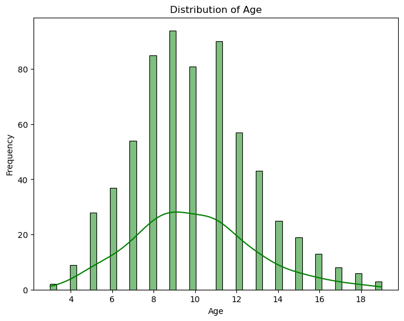

```python
# Distribution of Age
plt.figure(figsize=(8, 6))
sns.histplot(lungcapacity_df['Age'], kde=True, color='green', bins=50)
plt.title('Distribution of Age')
plt.xlabel('Age')
plt.ylabel('Frequency')
plt.show()
```

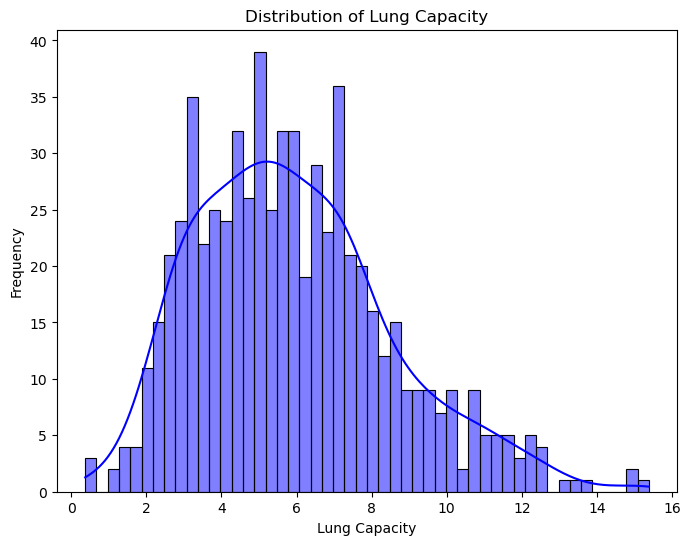

```python
# Distribution of Lung Capacity
plt.figure(figsize=(8, 6))
sns.histplot(lungcapacity_df['LungCap'], kde=True, color='blue', bins=50)
plt.title('Distribution of Lung Capacity')
plt.xlabel('Lung Capacity')
plt.ylabel('Frequency')
plt.show()
```

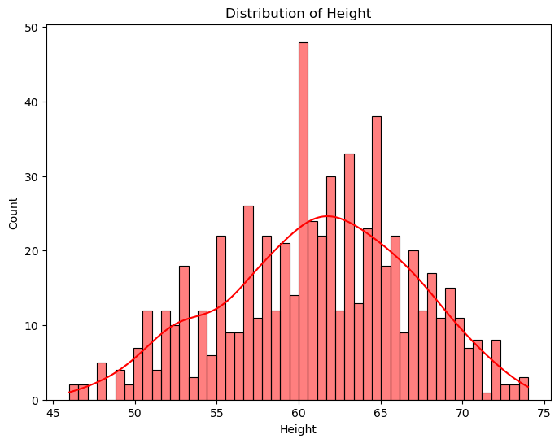

```python
# Distribution of Height
plt.figure(figsize=(8, 6))
sns.histplot(lungcapacity_df['Height'], kde=True, color='red',bins=50)
plt.title('Distribution of Height')
```

### Distribution of Height

##### The distrbution for Height suggests variability in height among individuals. The middle 50% of the data (interquartile range) falls between 57 and 65.5 inches.

```python
# Count the occurrences of each gender
gender_counts = lungcapacity_df['Gender'].value_counts()
print("Occurrences of each gender:\n", gender_counts)
```

```
Occurrences of each gender:
 Gender
male      336
female    318
Name: count, dtype: int64
```

[figure not shown]

```python
# Visualize the count of occurrences for each gender
plt.figure(figsize=(6, 4))
sns.countplot(x='Gender', data=lungcapacity_df, palette='viridis')
plt.title('Occurrences of Each Gender')
plt.xlabel('Gender')
plt.ylabel('Count')
plt.xticks(ticks=range(len(gender_counts)), labels=gender_counts.index)
plt.show()
```

```python
# Count the occurrences of smoking status
smoking_counts = lungcapacity_df['Smoke'].value_counts()
print("Occurrences of smoking status:\n", smoking_counts)
```

```
Occurrences of smoking status:
 Smoke
no     589
yes     65
Name: count, dtype: int64
```

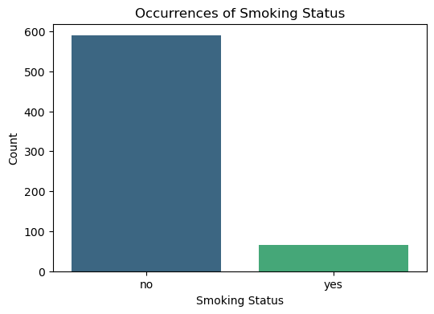

```python
# Visualize the count of occurrences for smoking status
plt.figure(figsize=(6, 4))
sns.countplot(x='Smoke', data=lungcapacity_df, palette='viridis')
plt.title('Occurrences of Smoking Status')
plt.xlabel('Smoking Status')
plt.ylabel('Count')
plt.xticks(ticks=range(len(smoking_counts)), labels=smoking_counts.index)
plt.show()
```

```python
# Convert categorical variables to numeric using one-hot encoding
lungcapacity_df_encoded = pd.get_dummies(lungcapacity_df, columns=['Gender', 'Smoke'], drop_first=True)
```

```python
# Correlation matrix
correlation_matrix = lungcapacity_df_encoded.corr()
print("Correlation matrix:\n", correlation_matrix)
```

```
Correlation matrix:
                   Age   LungCap    Height  Gender_male  Smoke_yes
Age          1.000000  0.756459  0.791944     0.029144   0.404252
LungCap      0.756459  1.000000  0.868135     0.208415   0.245425
Height       0.791944  0.868135  1.000000     0.159029   0.280387
Gender_male  0.029144  0.208415  0.159029     1.000000  -0.075612
Smoke_yes    0.404252  0.245425  0.280387    -0.075612   1.000000
```

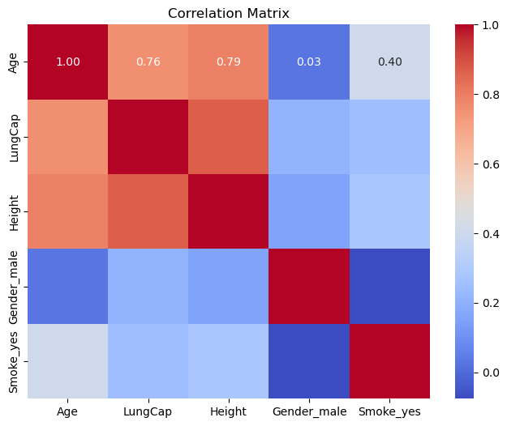

```python
# Heatmap of correlation matrix
plt.figure(figsize=(8, 6))
sns.heatmap(correlation_matrix, annot=True, cmap='coolwarm', fmt=".2f", annot_kws={"size": 10})
plt.title('Correlation Matrix')
plt.show()
```

### This heatmap shows positive correlation between height, lungcap, and age. Let's do correlation matrix only for numerical variables

```python
# Select columns 'Age', 'LungCap', and 'Height' for correlation matrix
selected_columns = ['Age', 'LungCap', 'Height']
correlation_matrix = lungcapacity_df[selected_columns].corr()
```

```python
# Print correlation matrix
print("Correlation matrix for Age, LungCap, and Height:\n", correlation_matrix)
```

```
Correlation matrix for Age, LungCap, and Height:
               Age   LungCap    Height
Age      1.000000  0.756459  0.791944
LungCap  0.756459  1.000000  0.868135
Height   0.791944  0.868135  1.000000
```

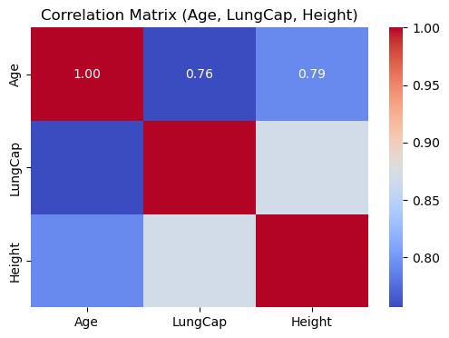

```python
# Heatmap of correlation matrix
plt.figure(figsize=(6, 4))
sns.heatmap(correlation_matrix, annot=True, cmap='coolwarm', fmt=".2f", annot_kws={"size": 10})
plt.title('Correlation Matrix (Age, LungCap, Height)')
plt.show()
```

```python
# Cross-tabulations between 'Gender' and 'Smoke'
cross_tab = pd.crosstab(lungcapacity_df['Gender'], lungcapacity_df['Smoke'])
print("Cross-tabulations between Gender and Smoke:\n", cross_tab)
```

```
Cross-tabulations between Gender and Smoke:
 Smoke    no  yes
Gender
female  279   39
male    310   26
```

```python
# Summary table comparing mean Lung Capacity across different genders
summary_gender = lungcapacity_df.groupby('Gender')['LungCap'].describe()
print("Summary table comparing mean LungCap across different genders:\n", summary_gender)
```

```
Summary table comparing mean LungCap across different genders:
         count      mean       std    min     25%    50%      75%     max
Gender
female  318.0  5.353509  1.937208  0.373  3.8455  5.458  6.97525   9.505
male    336.0  6.437339  3.010793  0.388  4.0255  5.818  8.60425  15.379
```

```python
# Summary table comparing mean Lung Capacity across different smoking statuses
summary_smoke = lungcapacity_df.groupby('Smoke')['LungCap'].describe()
print("Summary table comparing mean LungCap across different smoking statuses:\n", summary_smoke)
```

```
Summary table comparing mean LungCap across different smoking statuses:
        count      mean       std    min    25%    50%    75%     max
Smoke
no     589.0  5.698428  2.551565  0.373  3.760  5.395  7.144  15.379
yes     65.0  7.830585  2.249959  3.082  6.385  7.507  9.253  12.616
```

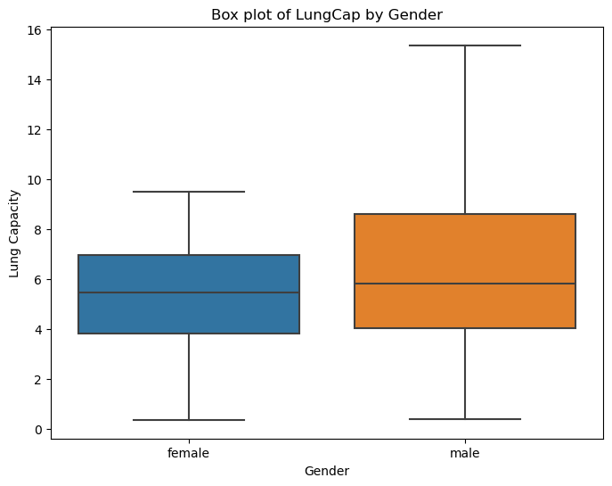

```python
# Box plot of Lung Capacity by Gender
plt.figure(figsize=(8, 6))
sns.boxplot(x='Gender', y='LungCap', data=lungcapacity_df)
plt.title('Box plot of LungCap by Gender')
plt.xlabel('Gender')
plt.ylabel('Lung Capacity')
plt.show()
```

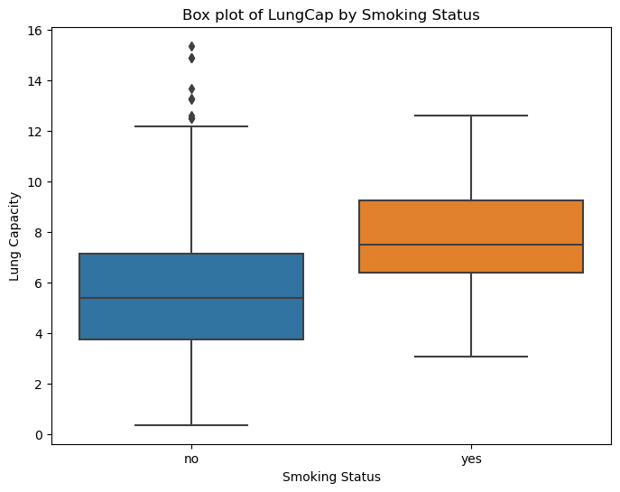

```python
# Box plot of Lung Capacity by Smoking Status
plt.figure(figsize=(8, 6))
sns.boxplot(x='Smoke', y='LungCap', data=lungcapacity_df)
plt.title('Box plot of LungCap by Smoking Status')
plt.xlabel('Smoking Status')
plt.ylabel('Lung Capacity')
plt.show()
```

#### The mean Lung Capacity for respondents who smoke ('yes') is indeed higher than for those who do not ('no'). However, this doesn't necessarily mean that smoking increases lung capacity. There could be other factors at play, such as age, gender, or overall health status, which could confound the relationship. Further investigation or controlled studies would be needed to establish a causal relationship.

#### Similar to the smoking status comparison, the mean LungCap for males is higher than for females. Again, this doesn't imply a direct causation between gender and lung capacity. Other factors, such as height, lifestyle, or genetic differences, may contribute to this observed difference.

#### The box plot shows the distribution of lung capacity values across genders. While there may be differences in the spread of lung capacity values between males and females, as indicated by the box plot, it's essential to consider other factors before drawing conclusions about any inherent differences in lung capacity between genders.

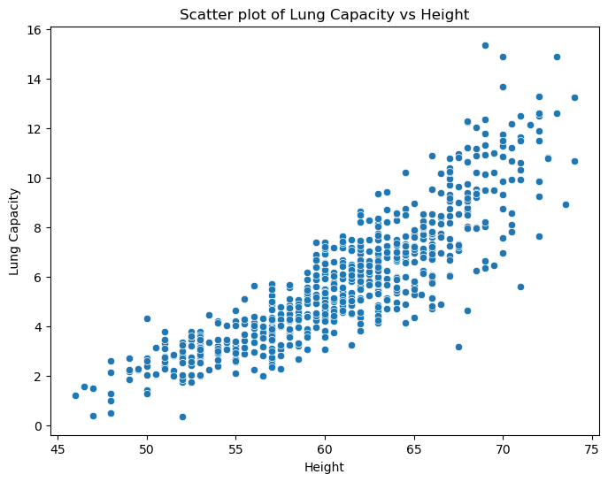

```python
# Scatter plot of Lung Capacity vs Height
plt.figure(figsize=(8, 6))
sns.scatterplot(x='Height', y='LungCap', data=lungcapacity_df)
plt.title('Scatter plot of Lung Capacity vs Height')
plt.xlabel('Height')
plt.ylabel('Lung Capacity')
plt.show()
```

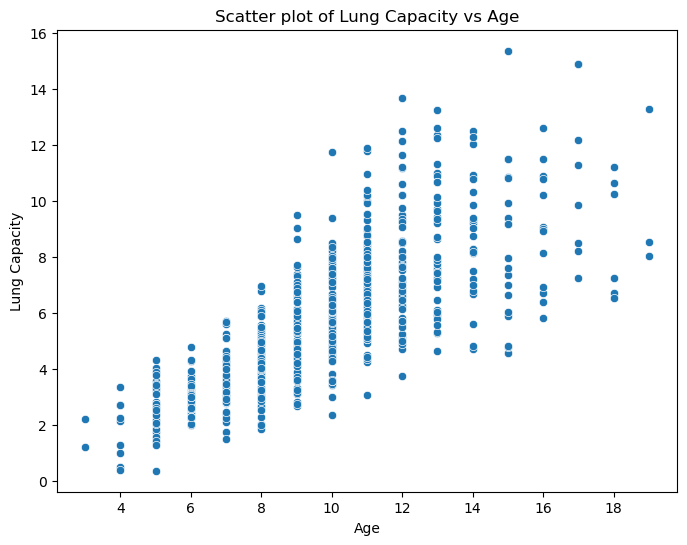

```python
# Scatter plot of Lung Capacity vs Age
plt.figure(figsize=(8, 6))
sns.scatterplot(x='Age', y='LungCap', data=lungcapacity_df)
plt.title('Scatter plot of Lung Capacity vs Age')
plt.xlabel('Age')
plt.ylabel('Lung Capacity')
plt.show()
```

#### Scatter plot of Lung Capacity vs Age

```python
from scipy.stats import chi2_contingency

# Create a contingency table between 'Gender' and 'Smoke'
contingency_table = pd.crosstab(lungcapacity_df['Gender'], lungcapacity_df['Smoke'])
```

```python
# Perform the chi-square test
chi2_stat, p_val, dof, expected = chi2_contingency(contingency_table)
```

```python
# Print the results
print("Chi-square statistic:", chi2_stat)
print("P-value:", p_val)
print("Degrees of freedom:", dof)
print("Expected frequencies:\n", expected)
```

```
Chi-square statistic: 3.2504476067386507
P-value: 0.07140395600974679
Degrees of freedom: 1
Expected frequencies:
 [[286.39449541  31.60550459]
 [302.60550459  33.39449541]]
```

```python
# Determine the significance of the results
alpha = 0.05  # significance level
if p_val < alpha:
    print("There is a significant association between Gender and Smoking Status.")
else:
    print("There is no significant association between Gender and Smoking Status.")
```

```
There is no significant association between Gender and Smoking Status.
```

```python
# Additional information on who smokes and who doesn't by gender
smoking_by_gender = lungcapacity_df.groupby('Gender')['Smoke'].value_counts()
print("\nSmoking status by gender:\n", smoking_by_gender)
```

```
Smoking status by gender:
 Gender  Smoke
female  no       279
        yes       39
male    no       310
        yes       26
Name: count, dtype: int64
```

## Models to explore the nature of the relationship between variables

##### The null hypothesis in the context of ANOVA tests for model comparison typically states that the reduced model (the simpler model being compared) is sufficient to explain the variation in the response variable, and there is no significant improvement in model fit by adding additional terms.

#### Model 1 vs Model 2:

##### Null hypothesis: The simpler model (Model 1) with only the linear term for height is sufficient to explain the variation in lung capacity. Adding the quadratic term (Model 2) does not significantly improve the model fit.

#### Model 2 vs Model 3:

##### Null hypothesis: The model with the linear and quadratic terms (Model 2) is sufficient to explain the variation in lung capacity. Adding the cubic term (Model 3) does not significantly improve the model fit beyond what is captured by the linear and quadratic terms.

##### In both cases, the alternative hypothesis is that adding the additional terms significantly improves the model fit. The p-value associated with the F-statistic in the ANOVA output indicates the probability of observing such a significant improvement in model fit under the null hypothesis. If the p-value is below a chosen significance level (e.g., 0.05), we reject the null hypothesis in favor of the alternative hypothesis, concluding that the more complex model provides a significant improvement in explaining the variation in the response variable.

```python
# Model 1: LungCap vs Height
model1 = ols('LungCap ~ Height', data=lungcapacity_df).fit()
```

```python
# Model 2: LungCap vs (Height + Height^2)
lungcapacity_df['Height_squared'] = lungcapacity_df['Height']**2
model2 = ols('LungCap ~ Height + Height_squared', data=lungcapacity_df).fit()
```

```python
# Model 3: LungCap vs (Height + Height^2 + Height^3)
lungcapacity_df['Height_cubed'] = lungcapacity_df['Height']**3
model3 = ols('LungCap ~ Height + Height_squared + Height_cubed', data=lungcapacity_df).fit()
```

```python
# ANOVA for Model 1 vs Model 2
anova_results1_2 = sm.stats.anova_lm(model1, model2)
print("ANOVA results for Model 1 vs Model 2:\n", anova_results1_2)
```

```
ANOVA results for Model 1 vs Model 2:
    df_resid          ssr  df_diff    ss_diff          F        Pr(>F)
0     652.0  1088.405828      0.0        NaN        NaN           NaN
1     651.0   998.092326      1.0  90.313502  58.906464  6.068515e-14
```

```python
# ANOVA for Model 2 vs Model 3
anova_results2_3 = sm.stats.anova_lm(model2, model3)
print("\nANOVA results for Model 2 vs Model 3:\n", anova_results2_3)
```

```
ANOVA results for Model 2 vs Model 3:
    df_resid         ssr  df_diff   ss_diff        F    Pr(>F)
0     651.0  998.092326      0.0       NaN      NaN       NaN
1     650.0  997.791669      1.0  0.300658  0.19586  0.658231
```

### Model 1 vs Model 2:

#### The F-statistic is significant (F = 58.91, p < 0.05), indicating that Model 2, with the quadratic term, significantly improves the model fit compared to Model 1.

#### Therefore, the quadratic term adds explanatory power to the model, leading to a better fit.

#### Therefore, we reject the null hypothesis and conclude that Model 2 provides a significant improvement in explaining the variation in lung capacity compared to Model 1.

### Model 2 vs Model 3:

#### The F-statistic is not significant (F = 0.196, p > 0.05), suggesting that Model 3, with the cubic term, does not provide a significant improvement in fit compared to Model 2.

#### Therefore, including the cubic term in Model 3 does not significantly enhance the model beyond the quadratic term in Model 2.

#### Therefore, we fail to reject the null hypothesis, suggesting that Model 3 does not provide a significant improvement in explaining the variation in lung capacity beyond what is captured by Model 2.

#### Data Visualization of models

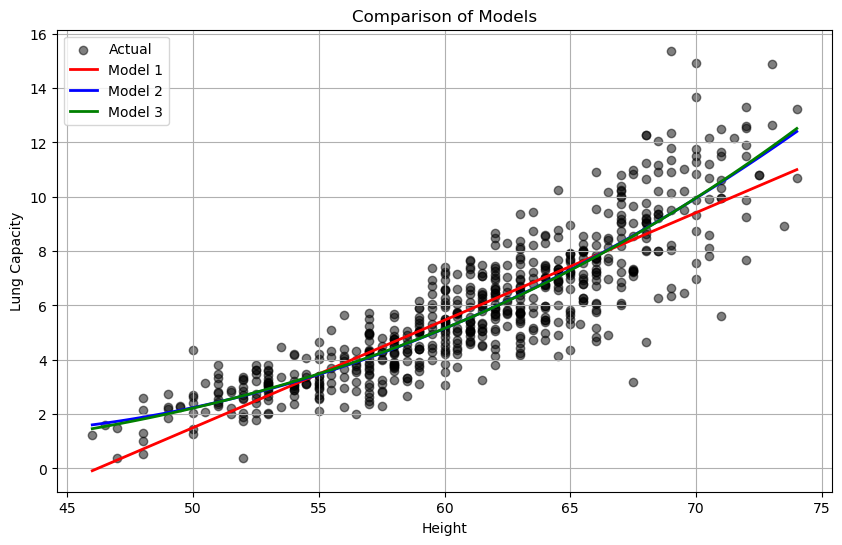

```python
# Create a range of values for Height
height_values = np.linspace(lungcapacity_df['Height'].min(), lungcapacity_df['Height'].max(), 100)

# Predictions for each model
model1_predictions = model1.predict({'Height': height_values})
model2_predictions = model2.predict({'Height': height_values, 'Height_squared': height_values**2})
model3_predictions = model3.predict({'Height': height_values, 'Height_squared': height_values**2, 'Height_cubed': height_values**3})

# Plot all 3 models
plt.figure(figsize=(10, 6))
plt.scatter(lungcapacity_df['Height'], lungcapacity_df['LungCap'], color='black', label='Actual', alpha=0.5)
plt.plot(height_values, model1_predictions, color='red', label='Model 1', linewidth=2)
plt.plot(height_values, model2_predictions, color='blue', label='Model 2', linewidth=2)
plt.plot(height_values, model3_predictions, color='green', label='Model 3', linewidth=2)
plt.xlabel('Height')
plt.ylabel('Lung Capacity')
plt.title('Comparison of Models')
plt.legend()
plt.grid(True)
plt.show()
```

```python
# Create tables for coefficients and goodness-of-fit statistics
tables = [model1.summary().tables[1], model2.summary().tables[1], model3.summary().tables[1]]
titles = ['Model 1 Coefficients', 'Model 2 Coefficients', 'Model 3 Coefficients']

for title, table in zip(titles, tables):
    print(title)
    print(table)

print("\nModel 1 R-squared:", model1.rsquared)
print("Model 2 R-squared:", model2.rsquared)
print("Model 3 R-squared:", model3.rsquared)
```

[output not shown]

### Model 1:

##### Coefficients: The constant term (intercept) is -18.2980, and the coefficient for the height variable is 0.3959. This means that for every one-unit increase in height, the lung capacity increases by approximately 0.3959 units.

##### Goodness-of-fit (R-squared): The R-squared value is 0.7537, indicating that approximately 75.37% of the variability in lung capacity is explained by the height variable in this model.

### Model 2:

##### Coefficients: The constant term is 16.0806, the coefficient for the height variable is -0.7501, and the coefficient for the height squared variable is 0.0095. This model includes a quadratic term for height. The negative coefficient for the height variable suggests a downward trend, while the positive coefficient for the height squared variable suggests a curvature in the relationship between height and lung capacity.

##### Goodness-of-fit (R-squared): The R-squared value is 0.7741, indicating that approximately 77.41% of the variability in lung capacity is explained by the height and height squared variables in this model.

### Model 3:

##### Coefficients: The constant term is -0.6293, the coefficient for the height variable is 0.0918, the coefficient for the height squared variable is -0.0046, and the coefficient for the height cubed variable is 0.00007739. This model includes both quadratic and cubic terms for height.

##### Goodness-of-fit (R-squared): The R-squared value is 0.7742, indicating that approximately 77.42% of the variability in lung capacity is explained by the height, height squared, and height cubed variables in this model.

## Conclusion

### Model 2 and Model 3 both show improvements in R-squared compared to Model 1, suggesting better fit.

### However, Model 3 does not seem to provide a significant improvement over Model 2, as indicated by the similarity in their R-squared values and the non-significant coefficients for the cubic term in Model 3.

### In summary, both Model 2 and Model 3 provide better fits than Model 1, but there's no significant improvement from Model 2 to Model 3. Therefore, Model 2 may be preferred due to its simplicity unless there's a theoretical reason to include the cubic term.